# Módulo 2: Biologia da Conservação no Brasil: Trajetória e Infraestrutura de Pesquisa

Curso de Biologia da Conservação — PPGBV

2026-08-20

# Abertura

## Módulo 2

### Biologia da Conservação no Brasil: Trajetória, Biodiversidade e Infraestrutura de Pesquisa

Terça e quinta-feira, 8h–18h

## Recapitulando o Módulo 1

- Consolidação institucional da biologia da conservação (1980s–1990s)
- SCB (1987) e *Conservation Biology* (1988) (Meine et al. 2006)
- Transição: proteger a natureza *das* pessoas → *para* as pessoas (Dyke e Lamb 2020)
- Primeiras vozes latino-americanas: Diegues, Leff, Martínez-Alier, Ulloa

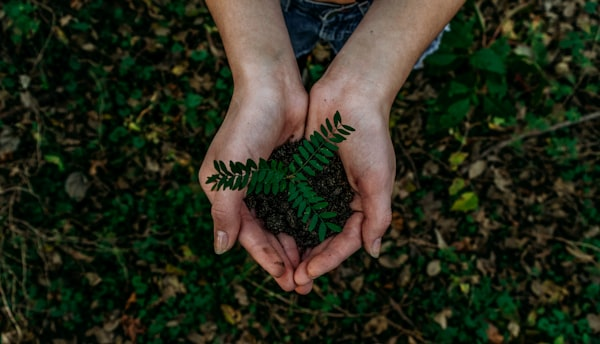

## Por que uma trajetória brasileira específica?

- O Brasil não é um “importador tardio” da conservação internacional
- Inovações institucionais próprias (reservas extrativistas)
- Megadiversidade + infraestrutura científica de escala continental
- Vulnerabilidade política recorrente

## Agenda de hoje

- **Terça, parte-1** — Trajetória da conservação no Brasil
- **Terça, parte-2** — Fundamentos de biodiversidade
- **Quinta, parte-3** — Infraestrutura científica brasileira
- **Quinta, parte-4** — Crise política e desmonte científico
- **Fechamento** — Perspectivas latino-americanas e síntese

# Bloco 1 — Trajetória da Conservação no Brasil

## Duas trajetórias, duas temporalidades

|  | EUA | Brasil |
| --- | --- | --- |
| Origem | Sociedade científica (1987) | Práticas mescladas + academia |
| Liderança | Biólogos | Biólogos + Ambientalistas + Antropólogos, etc… |
| Inovação | A criação de uma disciplina | Participação de movimentos sociais |
| Estado atual | Expansão contínua | Cortes e desmonte recorrentes |

## Conservação antes da “biologia da conservação”

- Trajetória brasileira: raízes mais antigas que a formalização acadêmica
- Conservação sempre imbricada com ocupação territorial
- Conhecimento de povos indígenas e comunidades tradicionais preexistente
- Origem não é um marco único, mas um processo histórico longo (Mittermeier et al. 2005)

[figure not shown]

PN de Itatiaia

## Chico Mendes e o movimento dos seringueiros

- Líder sindical e seringueiro, Acre
- Mobilização ao longo da década de 1980
- Assassinado em dezembro de 1988
- Repercussão internacional imediata

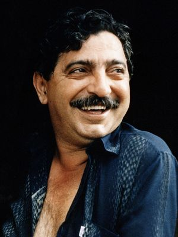

## A invenção da reserva extrativista

- Unidade de conservação de **uso sustentável**
- Reconhece direito de populações tradicionais à floresta pública
- Condicionada a práticas de manejo sustentável
- Modelo até então inédito na conservação global (Lovejoy 2005)

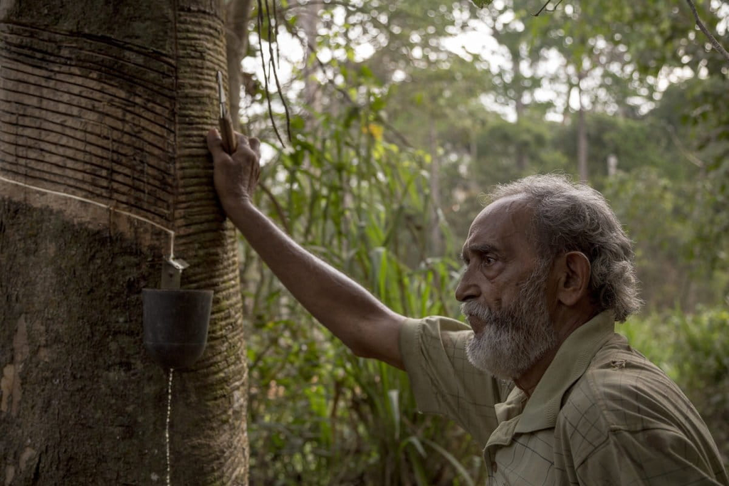

## De baixo para cima

**Importante**

A reserva extrativista nasceu da mobilização sindical dos seringueiros — não de um laboratório de política de conservação (Allegretti 2008).

- Negociada com o Estado sob forte pressão internacional
- Modelo com protagonismo social, não acadêmico

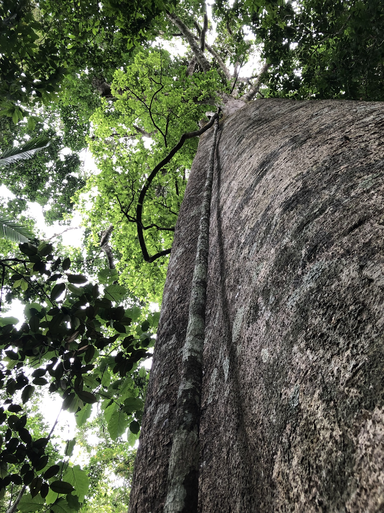

## Antecipando o debate internacional

- “proteger a natureza *para* as pessoas” (Dyke e Lamb 2020)
- Reservas extrativistas: mais de uma década antes
- Uma terceira formulação: conservação *pelas* pessoas
- Sujeitos políticos, não beneficiários passivos

[figure not shown]

## Consolidação do sistema de UCs

- Unidades de proteção integral **e** de uso sustentável
- Um dos sistemas de áreas protegidas mais extensos do mundo
- Comunidade científica de escala comparável a potências tradicionais (Mittermeier et al. 2005)

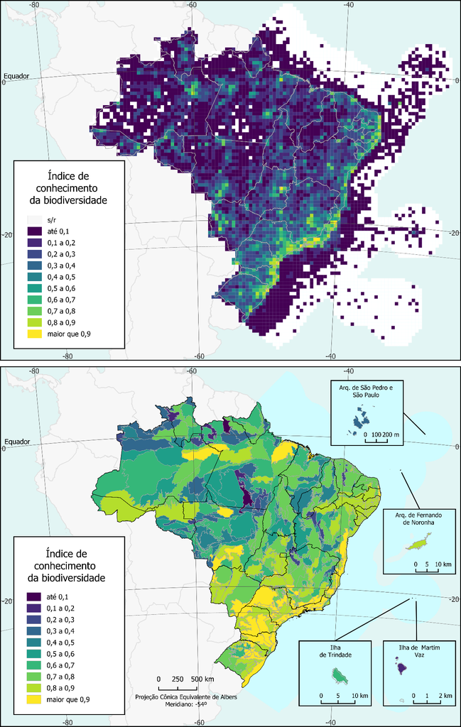

## Três frentes de liderança científica

1. Monitoramento por satélite (PRODES/INPE)
2. Redução histórica do desmatamento (meados dos anos 2000–2010s)
3. Proteção formal de territórios indígenas

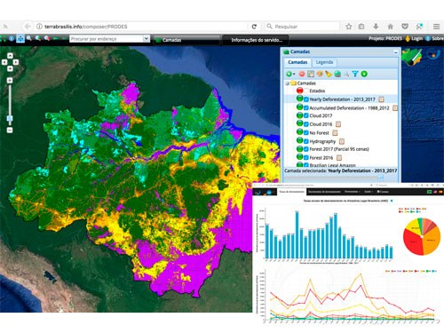

## Estudo de caso: São Paulo

- Articulação entre pesquisa, formação e política pública
- Programas estaduais de fomento à biodiversidade
- Desloca o foco da escala amazônica
- Mata Atlântica como território de política científica (Joly et al. 2010)

[figure not shown]

## Para discussão

**Nota**

Por que a reserva extrativista é mais citada em manuais internacionais do que estudada em currículos brasileiros de pós-graduação?

## Síntese do Bloco 1

- Trajetória brasileira: temporalidade e protagonists próprios
- Inovação institucional nascida de mobilização social
- Liderança científica construída ao longo de décadas
- Tensão permanente: conquista científica × vulnerabilidade política

# Bloco 2 — Fundamentos de Biodiversidade

## O que é biodiversidade?

Variabilidade em três níveis hierarquicamente aninhados

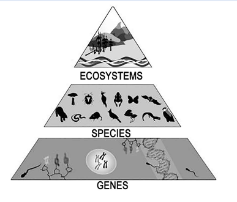

## Nível 1 — Diversidade genética

- Variação de genes dentro e entre populações
- Base da capacidade adaptativa futura
- Erosão genética compromete resposta a mudanças ambientais

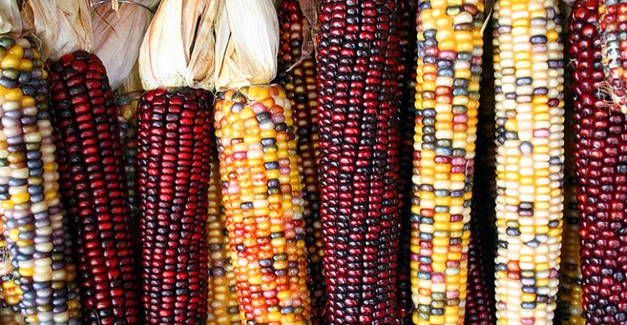

## Nível 2 — Diversidade de espécies

- Número e abundância relativa de espécies
- Acepção mais intuitiva do termo “biodiversidade”
- A mais comunicada ao público leigo

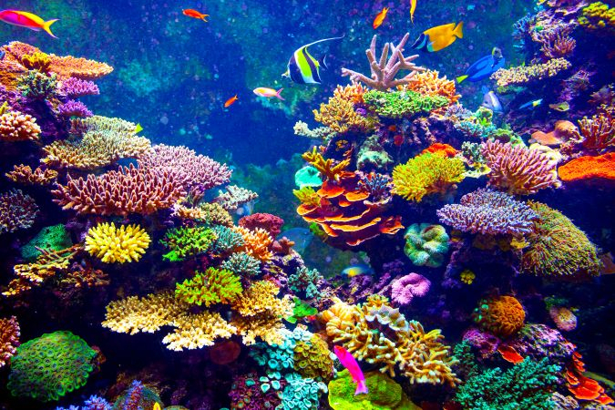

## Nível 3 — Diversidade de ecossistemas

- Variedade de habitats e comunidades bióticas
- Heterogeneidade de interações espécie-ambiente
- Processos ecológicos em escala de paisagem

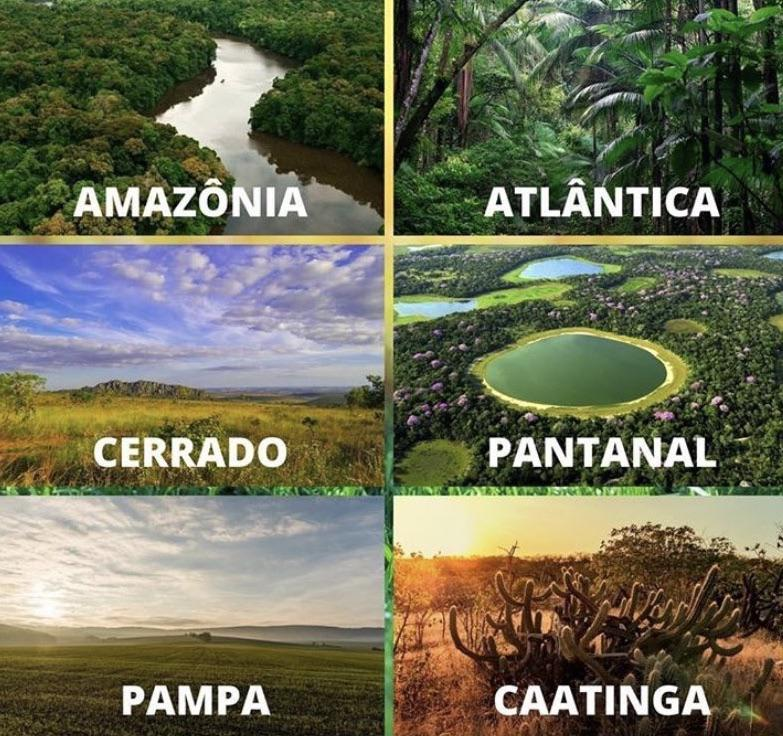

## Os três níveis não são substituíveis

**Importante**

Um cenário pode manter riqueza de espécies **enquanto perde** diversidade genética — ou vice-versa.

- Avaliações com um único nível subestimam perdas
- Necessário monitorar múltiplos níveis simultaneamente

[figure not shown]

## Escala importa: alfa, beta e gama

- **Alfa**: riqueza local, em um único ponto
- **Beta**: diferença de composição entre locais
- **Gama**: riqueza total da região (α + β)

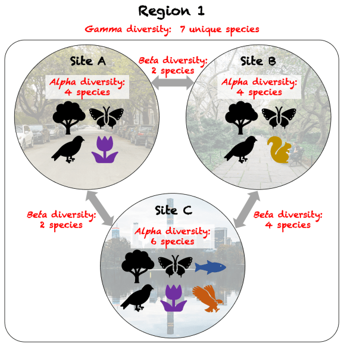

## Diversidade beta: um caso contraintuitivo

- Atividades humanas podem **aumentar ou diminuir** a beta-diversidade
- Depende do equilíbrio entre dois processos opostos
- Não existe direção única de resposta (Socolar et al. 2015)

## Heterogeneização vs. homogeneização biótica

[output not shown]

## A armadilha da leitura ingênua

**Importante**

Aumento aparente de diversidade beta pode mascarar homogeneização biótica em curso (Socolar et al. 2015).

- Dados de composição precisam ser lidos junto com identidade funcional
- Contagens brutas de diferenciação não bastam

[figure not shown]

## Ecologia de metacomunidades

- Arcabouço teórico para diversidade beta em escala de paisagem
- Modela dispersão, interações e filtragem ambiental
- Conecta comunidades espacialmente estruturadas
- Cada vez mais associado à literatura de conservação (Chase et al. 2020)

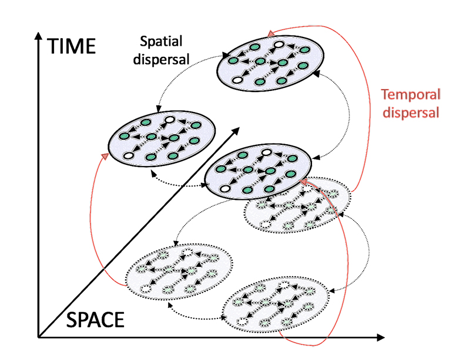

## Os motores diretos da perda de biodiversidade

Revisão sistemática global identifica hierarquia empírica robusta (Jaureguiberry et al. 2022)

## Motor #1: mudança de uso da terra

- Conversão e degradação de habitats naturais
- Agricultura, pecuária, infraestrutura, urbanização
- **O motor dominante** em escala global

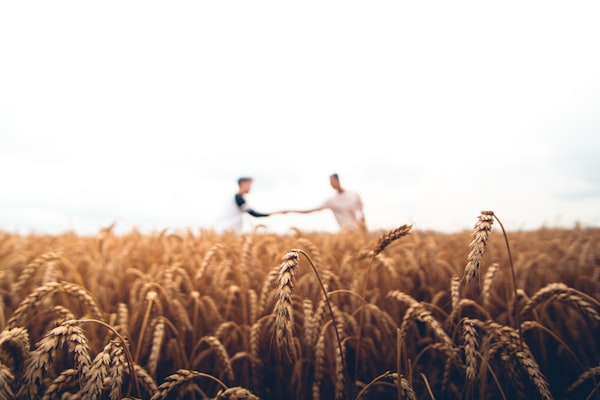

## Motor #2: exploração direta

- Caça, pesca e coleta insustentáveis
- Segundo lugar na hierarquia empírica
- Interage com mudança de uso da terra

[figure not shown]

## E as mudanças climáticas?

**Nota**

Contrariando a percepção pública comum, mudanças climáticas **não** lideram a hierarquia de motores diretos — ainda que interajam sinergicamente com os demais (Jaureguiberry et al. 2022).

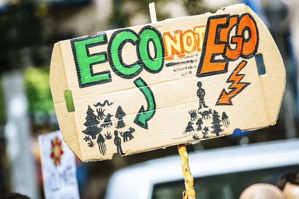

## Implicação para o Brasil

- Desmatamento continua como variável mais explicativa
- Amazônia, Cerrado e Mata Atlântica
- Monitoramento territorial: instrumento científico central

[figure not shown]

## Biodiversidade e sustentabilidade: cinco prioridades

1. Serviços ecossistêmicos que beneficiam humanos
2. Conexão entre biodiversidade e redução da pobreza
3. Agricultura biodiversa
4. Conhecimento indígena e tradicional
5. Indicadores integrados (Niesenbaum 2019)

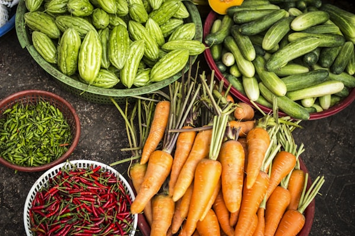

## Síntese do Bloco 2

- Biodiversidade: três níveis, três escalas
- Diversidade beta responde de forma contraintuitiva
- Mudança de uso da terra: motor dominante de perda
- Conservação e sustentabilidade: agendas articuláveis, não opostas

# Bloco 3 — Infraestrutura Científica Brasileira

## O desafio da megadiversidade

- Território continental
- Seis biomas: Amazônia, Cerrado, Mata Atlântica, Caatinga, Pantanal, Pampa
- Assimetria histórica de capacidade científica regional
- Escala como problema institucional, não só ecológico

## PPBio: Programa de Pesquisa em Biodiversidade

- Em operação desde 2004
- Integra pesquisadores, gestores e formuladores de política
- Metodologia padronizada de amostragem (Rosa et al. 2021)

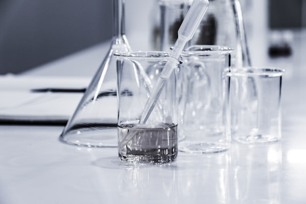

## PPBio em números

- **161** sítios de pesquisa de longo prazo
- **626** pesquisadores
- **9** redes regionais
- **~1.200** publicações científicas (Rosa et al. 2021; Fernandes et al. 2017)

[figure not shown]

## Por que padronização importa

**Importante**

Protocolos comuns tornam dados de pontos distantes **comparáveis entre si** — raro em programas de escala continental.

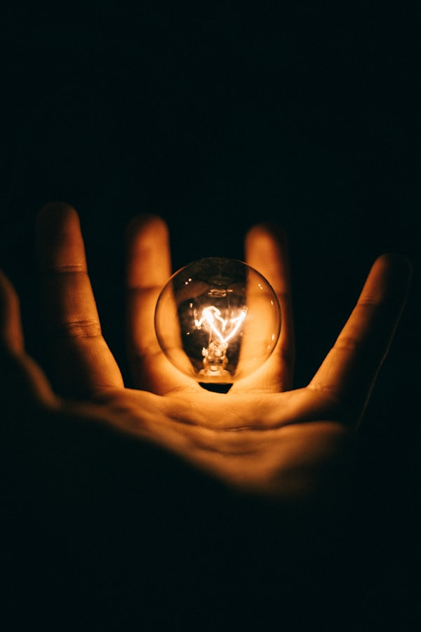

## O papel formativo do PPBio

- Capacitação técnica local
- Formação de centenas de estudantes
- Rede de pesquisadores hoje distribuída pelo país
- Possíveis orientadores/colaboradores dos próprios alunos

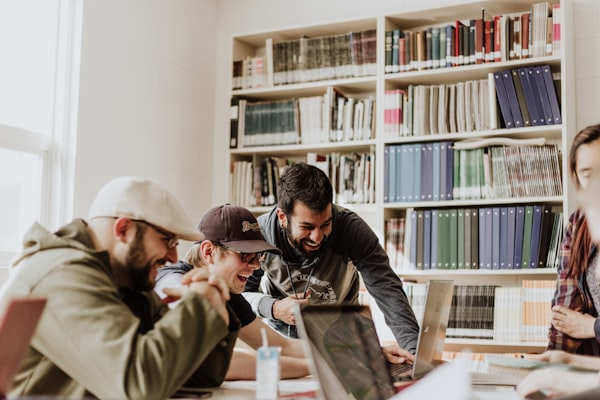

## O ponto frágil do PPBio

**Nota**

Principal desafio: financiamento de longo prazo sustentado (Rosa et al. 2021).

*(conecta diretamente ao Bloco 4)*

## GBB: Genômica da Biodiversidade Brasileira

- Consórcio de governança **público-privada**
- Escala continental
- Sequenciamento genômico de espécies de interesse (Vilaça et al. 2024)

[figure not shown]

## Por que a genômica importa aqui

- Resolução inatingível por métodos morfológicos/ecológicos
- Acessa diretamente o **nível genético** de biodiversidade
- Insumo científico **e** insumo de política pública

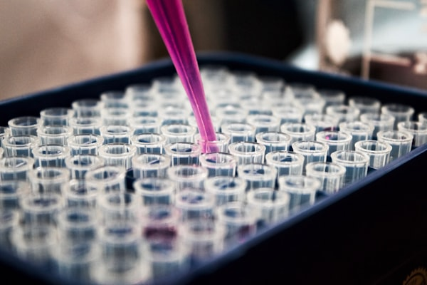

## GBB: conservação + bioeconomia

- Modelo de integração explícita entre os dois campos
- Ilustra concretamente a proposta de Niesenbaum (2019)
- Convocação a outros países megadiversos (Vilaça et al. 2024)

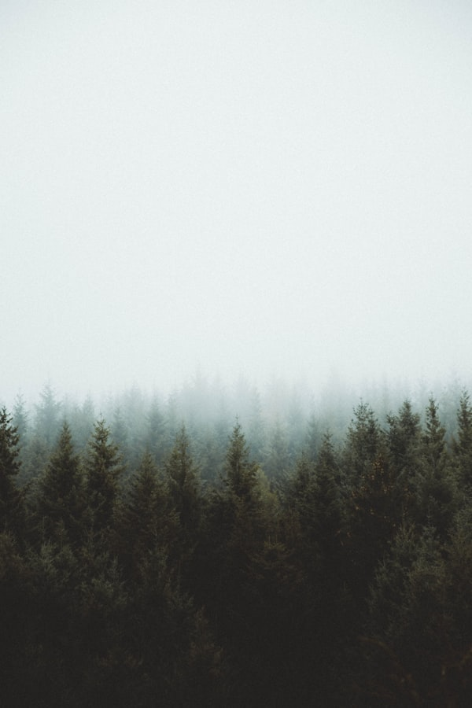

## Um raro fluxo Sul–Sul

**Nota**

Inovação institucional brasileira proposta como modelo para outros países megadiversos — sem mediação de instituições do Hemisfério Norte.

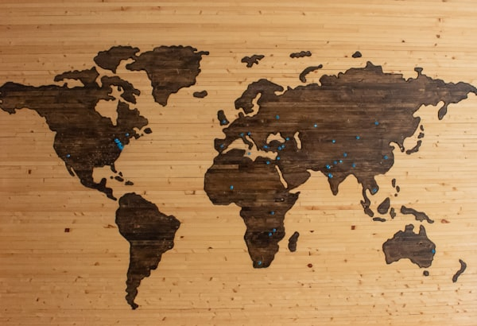

## Paleobiologia da conservação

- Usa tafonomia para reconstruir condições pré-impacto humano
- Gera linhas de base históricas
- América do Sul: geologia singular, riqueza fóssil (De Assumpção e Ritter 2025)

[figure not shown]

## Sub-representação com um porém

- América do Sul: **~5%** das publicações globais da área
- Brasil: **~2/3** dessa fração regional
- CNPq: **3º lugar mundial** em financiamento da área (De Assumpção e Ritter 2025)

## Um descompasso a discutir

**Importante**

Investimento financeiro elevado, visibilidade internacional baixa. Por quê?

*(pista: barreiras linguísticas — Módulo 3)*

## Três pilares, uma infraestrutura

- PPBio: rede pública, ecologia de campo
- GBB: consórcio público-privado, genômica
- Paleobiologia: reconstrução histórica de longo prazo
- Juntos, tornam possível falar de “biodiversidade brasileira” em escala nacional

## Para discussão

**Nota**

Compare a governança do PPBio (pública) com a do GBB (público-privada). Que perguntas científicas cada modelo responde melhor? Que tensões a parceria privada pode gerar?

## Síntese do Bloco 3

- Infraestrutura de escala continental, multimetodológica
- Formação de pesquisadores como ativo de longo prazo
- Modelo genuinamente brasileiro de integração ciência-política
- Infraestrutura robusta, porém vulnerável